# Renting With Airbnb in NYC

This jupyter notebook contains the steps I took for my analysis including exploring the data. This project follows CRISP-DM and below you will find a table of contents to quickly go through each section of CRISP-DM. Under the question header I explain my rationale for pursuing that specific question. Under Prepare Data I explain the steps I take to prepare the data for the analysis and under Model Data I explain what I'm plotting and why. Finally, we discuss the results under the Results section.

## Business Understanding:

The questions I looked at are:

- Question 1: Are there any good naming conventions for postings?
  - 1.1 Prepare Data
  - 1.2 Model Data
  - 1.3 Results
- Question 2: What room types are there and what can we find in the various neighborhoods of NYC?
  - 2.1 Prepare Data
  - 2.2 Model Data
  - 2.3 Results
- Question 3: Which neighborhood is best to optimize both price and traffic?
  - 3.1 Prepare Data
  - 3.2 Model Data
  - 3.3 Results

For the questions I decided on a common theme of "What should I know if I wanted to rent out a space in NYC on AirBnB?"

## Data Understanding

Below I explored the data I am using.

```python
import pandas as pd
import numpy as np

df = pd.read_csv('AB_NYC_2019.csv')

df.head()
```

|  | id | name | host_id | host_name | neighbourhood_group | neighbourhood | latitude | longitude | room_type | price | minimum_nights | number_of_reviews | last_review | reviews_per_month | calculated_host_listings_count | availability_365 |
| --- | --- | --- | --- | --- | --- | --- | --- | --- | --- | --- | --- | --- | --- | --- | --- | --- |
| 0 | 2539 | Clean & quiet apt home by the park | 2787 | John | Brooklyn | Kensington | 40.64749 | -73.97237 | Private room | 149 | 1 | 9 | 2018-10-19 | 0.21 | 6 | 365 |
| 1 | 2595 | Skylit Midtown Castle | 2845 | Jennifer | Manhattan | Midtown | 40.75362 | -73.98377 | Entire home/apt | 225 | 1 | 45 | 2019-05-21 | 0.38 | 2 | 355 |
| 2 | 3647 | THE VILLAGE OF HARLEM....NEW YORK ! | 4632 | Elisabeth | Manhattan | Harlem | 40.80902 | -73.94190 | Private room | 150 | 3 | 0 | NaN | NaN | 1 | 365 |
| 3 | 3831 | Cozy Entire Floor of Brownstone | 4869 | LisaRoxanne | Brooklyn | Clinton Hill | 40.68514 | -73.95976 | Entire home/apt | 89 | 1 | 270 | 2019-07-05 | 4.64 | 1 | 194 |
| 4 | 5022 | Entire Apt: Spacious Studio/Loft by central park | 7192 | Laura | Manhattan | East Harlem | 40.79851 | -73.94399 | Entire home/apt | 80 | 10 | 9 | 2018-11-19 | 0.10 | 1 | 0 |

```python
df.shape
```

```
(48895, 16)
```

```python
# Check mean in neighbourhood group
df.groupby(['neighbourhood_group']).mean()
```

| neighbourhood_group | id | host_id | latitude | longitude | price | minimum_nights | number_of_reviews | reviews_per_month | calculated_host_listings_count | availability_365 |
| --- | --- | --- | --- | --- | --- | --- | --- | --- | --- | --- |
| Bronx | 2.273492e+07 | 1.056099e+08 | 40.848305 | -73.884552 | 87.496792 | 4.560953 | 26.004583 | 1.837831 | 2.233731 | 165.758937 |
| Brooklyn | 1.825685e+07 | 5.671526e+07 | 40.685036 | -73.951190 | 124.383207 | 6.056556 | 24.202845 | 1.283212 | 2.284371 | 100.232292 |
| Manhattan | 1.877494e+07 | 6.783062e+07 | 40.765062 | -73.974607 | 196.875814 | 8.579151 | 20.985596 | 1.272131 | 12.791330 | 111.979410 |
| Queens | 2.175500e+07 | 9.615680e+07 | 40.731531 | -73.872775 | 99.517649 | 5.181433 | 27.700318 | 1.941200 | 4.060184 | 144.451818 |
| Staten Island | 2.159747e+07 | 9.853360e+07 | 40.610225 | -74.105805 | 114.812332 | 4.831099 | 30.941019 | 1.872580 | 2.319035 | 199.678284 |

```python
df.groupby(['host_id']).mean().head(10)
```

| host_id | id | latitude | longitude | price | minimum_nights | number_of_reviews | reviews_per_month | calculated_host_listings_count | availability_365 |
| --- | --- | --- | --- | --- | --- | --- | --- | --- | --- |
| 2438 | 23669201.0 | 40.714120 | -73.944470 | 95.000000 | 45.0 | 1.0 | 0.06 | 1.0 | 0.000000 |
| 2571 | 1101224.0 | 40.686740 | -73.938450 | 182.000000 | 9.0 | 27.0 | 0.37 | 1.0 | 23.000000 |
| 2787 | 9370738.5 | 40.615155 | -73.974723 | 100.666667 | 1.0 | 17.5 | 0.48 | 6.0 | 235.333333 |
| 2845 | 9197974.5 | 40.753600 | -73.987835 | 162.000000 | 1.0 | 23.0 | 0.23 | 2.0 | 360.000000 |
| 2868 | 13234457.0 | 40.682580 | -73.958710 | 60.000000 | 29.0 | 2.0 | 0.06 | 1.0 | 221.000000 |
| 2881 | 6206192.0 | 40.683575 | -73.946870 | 58.500000 | 2.0 | 195.0 | 4.07 | 2.0 | 234.500000 |
| 3151 | 33245975.0 | 40.693160 | -73.967730 | 69.000000 | 1.0 | 1.0 | 0.67 | 1.0 | 179.000000 |
| 3211 | 4815848.0 | 40.763080 | -73.928430 | 90.000000 | 4.0 | 21.0 | 0.41 | 1.0 | 89.000000 |
| 3415 | 7208745.0 | 40.738590 | -73.788910 | 59.000000 | 3.0 | 4.0 | 0.09 | 1.0 | 365.000000 |
| 3563 | 4157064.0 | 40.640760 | -74.022400 | 35.000000 | 6.0 | 1.0 | 0.02 | 1.0 | 0.000000 |

```python
# Hosts with more than 1 listing
print(df.shape[0] - len(df['host_id'].unique()))
```

```
11438
```

```python
df['price'].describe()
```

```
count    48895.000000
mean       152.720687
std        240.154170
min          0.000000
25%         69.000000
50%        106.000000
75%        175.000000
max      10000.000000
Name: price, dtype: float64
```

```python
df['reviews_per_month'].describe()
```

```
count    38843.000000
mean         1.373221
std          1.680442
min          0.010000
25%          0.190000
50%          0.720000
75%          2.020000
max         58.500000
Name: reviews_per_month, dtype: float64
```

```python
# Check number of duplicated rows
df.duplicated().sum()
```

```
0
```

```python
# Check number of NAs in each row
df.isna().sum()
```

```
id                                    0
name                                 16
host_id                               0
host_name                            21
neighbourhood_group                   0
neighbourhood                         0
latitude                              0
longitude                             0
room_type                             0
price                                 0
minimum_nights                        0
number_of_reviews                     0
last_review                       10052
reviews_per_month                 10052
calculated_host_listings_count        0
availability_365                      0
dtype: int64
```

## Question 1: Are there any good naming conventions for postings?

When I personally look through postings on Airbnb, my first impression is formed by the title of the posting and the thumbnail that I see. Also, I know that certain words can induce a more comfortable feeling and make me want to stay at a place more, so I looked at what words I would use if I was a host.

### 1.1: Prepare Data

First, I need the top words, so I created a word count that saved to a file named counts.npz. Saving the word count information to a file is important because the function has a long runtime. This way, you only need to run the function once and read in the result every other time it's needed.

### Missing values/duplicates

In the name column that contains the name of the Airbnb posting, I simply removed those rows as we don't want NAN values when calculating most used words. In the same vein, I also removed rows that were duplicates as we duplicated rows could incorrectly inflate some words. We keep the first as then we have one row that is unique and remove the duplicates.

```python
from collections import Counter
import numpy as np
import nltk
from nltk.stem import WordNetLemmatizer
from nltk.tokenize import word_tokenize
from nltk.corpus import stopwords
nltk.download(['punkt', 'stopwords', 'wordnet'])

def compute_word_counts(messages, load=True, filepath='words_and_data/intermediate_files/counts.npz'):
    '''
    INPUT:
        messages - (list) List of messages to compute top words from, default is
        the list of names of airbnb listings
        load - (bool) By default true. If false will generate word counts
        filepath - (string) File path to save or load data

    OUTPUT:
        top_words - (list) Top words
        top_counts - (list) Top word counts

    '''
    if load:
        # load arrays
        data = np.load(filepath)
        return list(data['top_words']), list(data['top_counts'])
    else:
        # get top words
        counter = Counter()
        for message in messages:
            tokens = tokenize(message)
            for token in tokens:
                counter[token] += 1
        # top 20 words
        top = counter.most_common(20)
        top_words = [word[0] for word in top]
        top_counts = [count[1] for count in top]
        # save arrays
        np.savez(filepath, top_words=top_words, top_counts=top_counts)
        return list(top_words), list(top_counts)
```

```python
def tokenize(text):
    '''
    INPUT:
    text - (str) Takes text and standardizes it

    OUTPUT:
    tokens - (list) Tokenized text
    '''
    lower_text = text.lower()
    tokens = word_tokenize(lower_text)
    lemmatizer = WordNetLemmatizer()
    tokens = [words for words in tokens if words not in stopwords.words("english")]
    for element in tokens:
        lemmatizer.lemmatize(element)
    return tokens
```

```python
df_name = df['name']
```

```python
df_name.isna().sum()
```

```
16
```

```python
df_name.dropna(inplace=True)
```

```python
df_name.isna().sum()
```

```
0
```

```python
df_name.duplicated().sum()
```

```
974
```

```python
df_name.drop_duplicates(keep='first', inplace=True)
```

```python
df_name.duplicated().sum()
```

```
0
```

```python
df_name = df_name.to_numpy()
```

```python
compute_word_counts(df_name)
```

```
(['room',
  ',',
  '!',
  'bedroom',
  'private',
  'apartment',
  'cozy',
  'apt',
  'brooklyn',
  'studio',
  'spacious',
  '1',
  'manhattan',
  '2',
  '.',
  '&',
  'park',
  'east',
  'sunny',
  'williamsburg'],
 [10061,
  9047,
  7855,
  7585,
  7160,
  6657,
  5024,
  4578,
  4116,
  3973,
  3739,
  3521,
  3470,
  3268,
  3222,
  3182,
  3045,
  3010,
  2900,
  2624])
```

```python
# Get indices of words that contain cozy
index = []

for i in range(df.shape[0]):
    try:
        if df['name'].str.contains('cozy')[i] == True:
            index.append(i)
    except KeyError:
        continue
```

```python
print(len(index))
```

```
712
```

```python
import pickle
# Save the indices for the cozy dataframe to be made
with open('cozy_indices.pickle', 'wb') as handle:
    pickle.dump(index, handle, protocol=pickle.HIGHEST_PROTOCOL)
```

```python
# Save df_cozy
for i in range(len(index)):
    df_cozy = df_cozy.append(df.iloc[index[i]])

with open('df_cozy.pickle', 'wb') as handle:
    pickle.dump(df_cozy, handle, protocol=pickle.HIGHEST_PROTOCOL)
```

```python
df_cozy = pd.read_pickle('words_and_data/intermediate_files/df_cozy.pickle')
```

```python
df_cozy.head()
```

|  | id | name | host_id | host_name | neighbourhood_group | neighbourhood | latitude | longitude | room_type | price | minimum_nights | number_of_reviews | last_review | reviews_per_month | calculated_host_listings_count | availability_365 |
| --- | --- | --- | --- | --- | --- | --- | --- | --- | --- | --- | --- | --- | --- | --- | --- | --- |
| 60 | 15385 | Very, very cozy place | 60252 | Cristina | Brooklyn | Williamsburg | 40.71185 | -73.96204 | Private room | 80 | 2 | 42 | 2019-06-30 | 0.38 | 1 | 263 |
| 166 | 41513 | Convenient cozy cheap apt Manhattan | 181167 | Lorenzo | Manhattan | Harlem | 40.82704 | -73.94907 | Entire home/apt | 80 | 3 | 2 | 2015-11-02 | 0.04 | 1 | 0 |
| 170 | 43957 | Sunny cozy room in Brklyn townhouse | 177536 | Tessa | Brooklyn | Bushwick | 40.70641 | -73.91765 | Private room | 50 | 2 | 47 | 2019-06-19 | 0.94 | 1 | 37 |
| 199 | 53469 | cozy studio with parking spot | 204539 | Mark | Queens | Middle Village | 40.71722 | -73.87856 | Entire home/apt | 98 | 30 | 33 | 2015-05-09 | 0.31 | 5 | 240 |
| 270 | 64314 | cozy bedroom in lovely garden apt | 314256 | Debbie | Brooklyn | Crown Heights | 40.67610 | -73.95290 | Private room | 110 | 6 | 50 | 2019-05-26 | 3.55 | 1 | 0 |

### 1.2: Model Data

I decided to model the most used words without punctuation. This is becasue this provides a clear graphic for the frequency of certain words.

```python
import matplotlib.pyplot as plt
import seaborn as sns
def generate_word_count_figure(words, word_count, path_to_save):
    # Instantiate figure
    fig, ax = plt.subplots(figsize=(30, 10))
    # Set labels
    ax.set_xlabel('Words')
    ax.set_ylabel('Times Found')
    ax.set_title('Most Popular Words')
    plt.bar(words, word_count)
    # Save figure
    plt.savefig(path_to_save)
```

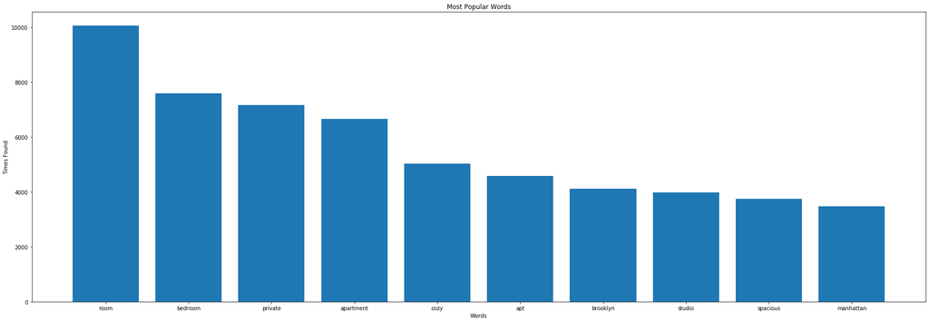

```python
top_words, counts = compute_word_counts(df_name,filepath='words_and_data/intermediate_files/counts.npz')
# Remove punctuation from the word counts
del top_words[1]
del top_words[1]
del counts[1]
del counts[1]
# Remove the number 1 from the list
del top_words[9]
del counts[9]

generate_word_count_figure(top_words[:10],
                           counts[:10], 'images/word_count.png')
```

### 1.3: Results

By comparing the reviews_per_month rows in the columns of postings that use "cozy" in the word, we have a good metric for which to determine the difference in traffic. It turns out that having "cozy" in the name of the posting does, on average, increase the traffic you'd be getting in 4 of the 5 major neighborhoods. Staten Island being the only exception.

```python
# Check difference between total average and places with 'cozy' in the name
df_cozy.groupby(['neighbourhood_group']).mean()['reviews_per_month'] - df.groupby(['neighbourhood_group']).mean()['reviews_per_month']
```

```
neighbourhood_group
Bronx            0.245327
Brooklyn         0.079834
Manhattan        0.225708
Queens           0.020943
Staten Island   -0.724008
Name: reviews_per_month, dtype: float64
```

```python
df_cozy.groupby(['neighbourhood_group'],as_index = False,sort=False).mean()
```

|  | neighbourhood_group | latitude | longitude | reviews_per_month |
| --- | --- | --- | --- | --- |
| 0 | Brooklyn | 40.679394 | -73.950250 | 1.363045 |
| 1 | Manhattan | 40.774802 | -73.968930 | 1.497839 |
| 2 | Queens | 40.739070 | -73.878652 | 1.962143 |
| 3 | Staten Island | 40.600528 | -74.115349 | 1.148571 |
| 4 | Bronx | 40.850700 | -73.881157 | 2.083158 |

## Question 2: What room types are there and what can we find in the various neighborhoods of NYC?

Personally, there are some types of spaces that I skip over when looking at Airbnb listings so I was interested in what types of spaces there were available. I first wanted to look into the types of rooms available and how many of each there were. Further, I wanted to see how likely it was to find the most common room type in each major neighborhood.

```python
df['neighbourhood_group'].unique()
```

```
array(['Brooklyn', 'Manhattan', 'Queens', 'Staten Island', 'Bronx'],
      dtype=object)
```

```python
df['room_type'].value_counts()
```

```
Entire home/apt    25409
Private room       22326
Shared room         1160
Name: room_type, dtype: int64
```

### Missing values/duplicates

Missing values are ignored as they are skipped when performing regression and there are no duplicated rows after calculating dummies.

```python
# Get dummies for neighbourhood_group
neigh_dummies = pd.get_dummies(df['neighbourhood_group'])
df_new = df.join(neigh_dummies)
df_new.head()
```

|  | id | name | host_id | host_name | neighbourhood_group | neighbourhood | latitude | longitude | room_type | price | ... | number_of_reviews | last_review | reviews_per_month | calculated_host_listings_count | availability_365 | Bronx | Brooklyn | Manhattan | Queens | Staten Island |
| --- | --- | --- | --- | --- | --- | --- | --- | --- | --- | --- | --- | --- | --- | --- | --- | --- | --- | --- | --- | --- | --- |
| 0 | 2539 | Clean & quiet apt home by the park | 2787 | John | Brooklyn | Kensington | 40.64749 | -73.97237 | Private room | 149 | ... | 9 | 2018-10-19 | 0.21 | 6 | 365 | 0 | 1 | 0 | 0 | 0 |
| 1 | 2595 | Skylit Midtown Castle | 2845 | Jennifer | Manhattan | Midtown | 40.75362 | -73.98377 | Entire home/apt | 225 | ... | 45 | 2019-05-21 | 0.38 | 2 | 355 | 0 | 0 | 1 | 0 | 0 |
| 2 | 3647 | THE VILLAGE OF HARLEM....NEW YORK ! | 4632 | Elisabeth | Manhattan | Harlem | 40.80902 | -73.94190 | Private room | 150 | ... | 0 | NaN | NaN | 1 | 365 | 0 | 0 | 1 | 0 | 0 |
| 3 | 3831 | Cozy Entire Floor of Brownstone | 4869 | LisaRoxanne | Brooklyn | Clinton Hill | 40.68514 | -73.95976 | Entire home/apt | 89 | ... | 270 | 2019-07-05 | 4.64 | 1 | 194 | 0 | 1 | 0 | 0 | 0 |
| 4 | 5022 | Entire Apt: Spacious Studio/Loft by central park | 7192 | Laura | Manhattan | East Harlem | 40.79851 | -73.94399 | Entire home/apt | 80 | ... | 9 | 2018-11-19 | 0.10 | 1 | 0 | 0 | 0 | 1 | 0 | 0 |

5 rows × 21 columns

```python
df_new.duplicated().sum()
```

```
0
```

```python
import statsmodels.api as sm;
```

```python
# Get dummies for room type
df_new[['Private room', 'Entire home/apt', 'Shared room']] = pd.get_dummies(df_new['room_type'])
```

```python
df_new.head()
```

|  | id | name | host_id | host_name | neighbourhood_group | neighbourhood | latitude | longitude | room_type | price | ... | calculated_host_listings_count | availability_365 | Bronx | Brooklyn | Manhattan | Queens | Staten Island | Private room | Entire home/apt | Shared room |
| --- | --- | --- | --- | --- | --- | --- | --- | --- | --- | --- | --- | --- | --- | --- | --- | --- | --- | --- | --- | --- | --- |
| 0 | 2539 | Clean & quiet apt home by the park | 2787 | John | Brooklyn | Kensington | 40.64749 | -73.97237 | Private room | 149 | ... | 6 | 365 | 0 | 1 | 0 | 0 | 0 | 0 | 1 | 0 |
| 1 | 2595 | Skylit Midtown Castle | 2845 | Jennifer | Manhattan | Midtown | 40.75362 | -73.98377 | Entire home/apt | 225 | ... | 2 | 355 | 0 | 0 | 1 | 0 | 0 | 1 | 0 | 0 |
| 2 | 3647 | THE VILLAGE OF HARLEM....NEW YORK ! | 4632 | Elisabeth | Manhattan | Harlem | 40.80902 | -73.94190 | Private room | 150 | ... | 1 | 365 | 0 | 0 | 1 | 0 | 0 | 0 | 1 | 0 |
| 3 | 3831 | Cozy Entire Floor of Brownstone | 4869 | LisaRoxanne | Brooklyn | Clinton Hill | 40.68514 | -73.95976 | Entire home/apt | 89 | ... | 1 | 194 | 0 | 1 | 0 | 0 | 0 | 1 | 0 | 0 |
| 4 | 5022 | Entire Apt: Spacious Studio/Loft by central park | 7192 | Laura | Manhattan | East Harlem | 40.79851 | -73.94399 | Entire home/apt | 80 | ... | 1 | 0 | 0 | 0 | 1 | 0 | 0 | 1 | 0 | 0 |

5 rows × 24 columns

```python
# Perform logistic regression to see how likely it is to find an Entire home/apt
df_new['intercept'] = 1

logit_mod = sm.Logit(df_new['Entire home/apt'], df_new[['intercept', 'Bronx', 'Brooklyn', 'Staten Island', 'Queens']])
results = logit_mod.fit()
results.summary()
```

```
Optimization terminated successfully.
         Current function value: 38.782459
         Iterations 4
```

Logit Regression Results

| Dep. Variable: | Entire home/apt | No. Observations: | 48895 |
| --- | --- | --- | --- |
| Model: | Logit | Df Residuals: | 48890 |
| Method: | MLE | Df Model: | 4 |
| Date: | Fri, 31 Jan 2020 | Pseudo R-squ.: | inf |
| Time: | 13:10:01 | Log-Likelihood: | -1.8963e+06 |
| converged: | True | LL-Null: | 0.0000 |
| Covariance Type: | nonrobust | LLR p-value: | 1.000 |

|  | coef | std err | z | P>\|z\| | [0.025 | 0.975] |
| --- | --- | --- | --- | --- | --- | --- |
| intercept | -0.5387 | 0.014 | -38.244 | 0.000 | -0.566 | -0.511 |
| Bronx | 0.9342 | 0.063 | 14.753 | 0.000 | 0.810 | 1.058 |
| Brooklyn | 0.5546 | 0.020 | 27.821 | 0.000 | 0.516 | 0.594 |
| Staten Island | 0.5548 | 0.105 | 5.308 | 0.000 | 0.350 | 0.760 |
| Queens | 0.9239 | 0.031 | 30.281 | 0.000 | 0.864 | 0.984 |

### 2.2: Model Data

Since the data that is being looked at is the room types, I decided to graph the counts for the various room types.

```python
def generate_room_type_figure(df, path_to_save):
    room_types = df['room_type'].value_counts().to_numpy()
    total = room_types.sum()
    labels = ['Entire home/apt', 'Private room', 'Shared room']
    # Instantiate figure
    fig, ax = plt.subplots(figsize=(30, 10))
    # Set labels
    ax.set_xlabel('Room Type')
    ax.set_ylabel('Percentage of Total')
    ax.set_title('Types of rooms in dataset')
    ax.set_ylim(0, 100)
    plt.bar(labels, (room_types/total)*100)
    # Save figure
    plt.savefig(path_to_save)
```

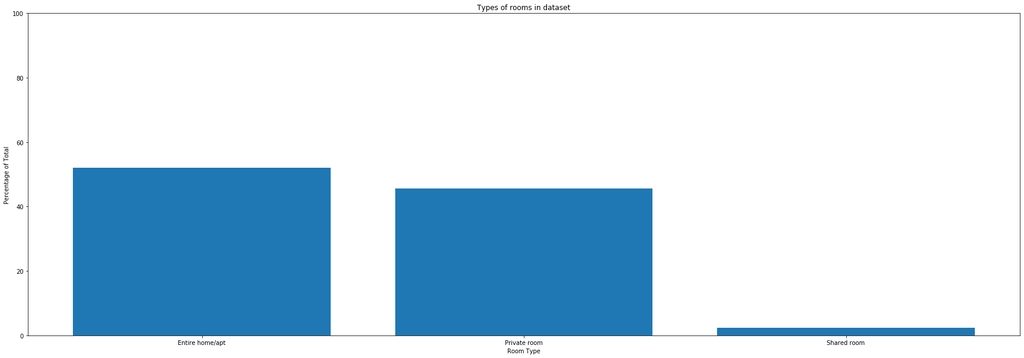

```python
generate_room_type_figure(df, 'images/room_types.png')
```

### 2.3: Results

```python
# Get multiplicative results
import math
bronx_logit = math.exp(0.9342)
brooklyn_logit = math.exp(0.5546)
staten_island_logit = math.exp(0.5548)
queens_logit = math.exp(0.9239)
print(bronx_logit, brooklyn_logit, staten_island_logit, queens_logit)
```

```
2.5451765018638044 1.7412443477168658 1.7415926314136176 2.5190957304427712
```

## Question 3: Which neighborhood is best to optimize both price and traffic?

Now that we have both an understanding of how to make a listing, and what time of spaces there are, it would be interesting to also know where a potential host would want to buy a space. By optimizing price and traffic in a neighborhood, we can approximate the neighborhood with the highest value for a potential host.

### 3.1: Prepare Data

To find the best neighborhood, the only step required in preparing the data is splitting up the dataframe into the 5 major neighborhoods.

### Missing values/duplicates

First, there are no duplicated values and so they are ignored. Next, while there are missing columns in the rows, they were ignored as when calculating mean() on the pandas dataframe, the rows are, by default, skipped over.

```python
# Split up dataframes based on neighbourhood group to see how each compare
df_manhattan = df[df['neighbourhood_group']=='Manhattan']
df_brooklyn = df[df['neighbourhood_group'] == 'Brooklyn']
df_queens = df[df['neighbourhood_group'] == 'Queens']
df_bronx = df[df['neighbourhood_group'] == 'Bronx']
df_staten_island = df[df['neighbourhood_group'] == 'Staten Island']
```

```python
# Get number of neighbourhoods in each group
print('Queens: ' + str(len(df_queens['neighbourhood'].unique())))
print('Brooklyn: ' + str(len(df_brooklyn['neighbourhood'].unique())))
print('Manhattan: ' + str(len(df_manhattan['neighbourhood'].unique())))
print('Staten Island: ' + str(len(df_staten_island['neighbourhood'].unique())))
print('Bronx: ' + str(len(df_bronx['neighbourhood'].unique())))
```

```
Queens: 51
Brooklyn: 47
Manhattan: 32
Staten Island: 43
Bronx: 48
```

```python
# Get duplicated amounts
print('Queens: ' + str(df_queens.duplicated().sum()))
print('Brooklyn: ' + str(df_brooklyn.duplicated().sum()))
print('Manhattan: ' + str(df_manhattan.duplicated().sum()))
print('Staten Island: ' + str(df_staten_island.duplicated().sum()))
print('Bronx: ' + str(df_bronx.duplicated().sum()))
```

```
Queens: 0
Brooklyn: 0
Manhattan: 0
Staten Island: 0
Bronx: 0
```

```python
# Get na rows in each group
print('Queens: ' + str(df_queens.isna().sum()))
print('Brooklyn: ' + str(df_brooklyn.isna().sum()))
print('Manhattan: ' + str(df_manhattan.isna().sum()))
print('Staten Island: ' + str(df_staten_island.isna().sum()))
print('Bronx: ' + str(df_bronx.isna().sum()))
```

```
Queens: id                                   0
name                                 0
host_id                              0
host_name                            2
neighbourhood_group                  0
neighbourhood                        0
latitude                             0
longitude                            0
room_type                            0
price                                0
minimum_nights                       0
number_of_reviews                    0
last_review                       1092
reviews_per_month                 1092
calculated_host_listings_count       0
availability_365                     0
dtype: int64
Brooklyn: id                                   0
name                                 6
host_id                              0
host_name                            9
neighbourhood_group                  0
neighbourhood                        0
latitude                             0
longitude                            0
room_type                            0
price                                0
minimum_nights                       0
number_of_reviews                    0
last_review                       3657
reviews_per_month                 3657
calculated_host_listings_count       0
availability_365                     0
dtype: int64
Manhattan: id                                   0
name                                 9
host_id                              0
host_name                            9
neighbourhood_group                  0
neighbourhood                        0
```

[output cut: 30 more lines]

```
host_id                             0
host_name                           1
neighbourhood_group                 0
neighbourhood                       0
latitude                            0
longitude                           0
room_type                           0
price                               0
minimum_nights                      0
number_of_reviews                   0
last_review                       215
reviews_per_month                 215
calculated_host_listings_count      0
availability_365                    0
dtype: int64
```

### 3.2: Model Data

To find the optimal price/traffic neighborhood, we take each split dataframe and group them again by their neighborhood. We then take the mean and find the price and reviews_per_month. We then plot each neighborhood_group side by side with a scatterplot where each dot represents a neighborhood in each neighborhood_group. I've added a line of best fit so we can have a good idea of the overall trend being followed in each neighborhood_group.

It is also very important to have each graph with the same xlim and ylim so as to not create a misleading graphic.

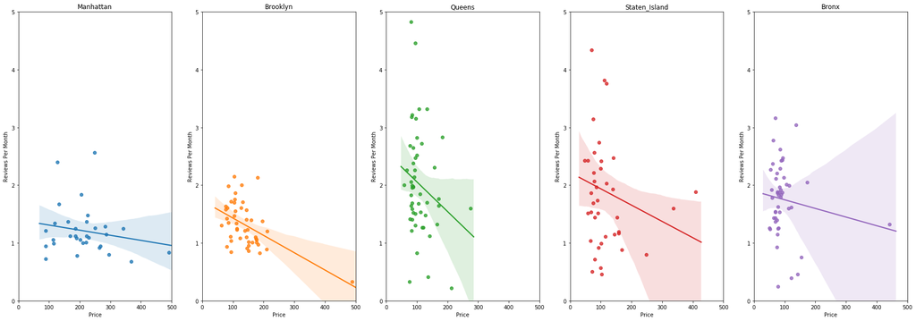

```python
# Plot price vs average reviews per month for each neighbourhood
# in each neighbourhood group. We put these side by side to analyze the results
name_list = ['Manhattan', 'Brooklyn', 'Queens', 'Staten_Island', 'Bronx']
fig, axs = plt.subplots(figsize=(30, 10),ncols=5)

sns.regplot(df_manhattan.groupby(['neighbourhood']).mean()['price'], df_manhattan.groupby(['neighbourhood']).mean()['reviews_per_month'], ax=axs[0]).set
sns.regplot(df_brooklyn.groupby(['neighbourhood']).mean()['price'], df_brooklyn.groupby(['neighbourhood']).mean()['reviews_per_month'], ax=axs[1])
sns.regplot(df_queens.groupby(['neighbourhood']).mean()['price'], df_queens.groupby(['neighbourhood']).mean()['reviews_per_month'],ax=axs[2])
sns.regplot(df_staten_island.groupby(['neighbourhood']).mean()['price'], df_staten_island.groupby(['neighbourhood']).mean()['reviews_per_month'],ax=axs[3])
sns.regplot(df_bronx.groupby(['neighbourhood']).mean()['price'], df_bronx.groupby(['neighbourhood']).mean()['reviews_per_month'], ax=axs[4])
for i in range(5):
    axs[i].set_title(name_list[i])
    axs[i].set_xlabel('Price')
    axs[i].set_ylabel('Reviews Per Month')
    axs[i].set_xlim(0,500)
    axs[i].set_ylim(0,5)
plt.show()
```

### 3.3: Results

Based on the above graph, we see that Bronx seems to have the best trend. We expect the line of best fit to show a negative correlation between the two and so we are trying to find the neighborhood that has the lowest negative trend. Both Manhattan and Bronx seem to have a similar line of best fit but, Bronx has a overall higher line and so higher traffic on average.